# Stats506 Final Project Report

Yan Chen, yanchann@umich.edu

December 13, 2020

## **Introduction**

Energy conservation is a hot issue nowadays. Energy can be conserved by reducing wastage and losses, improving efficiency through technological upgrades and improved operation and maintenance. In this project, I am working on the problem:

**Do buildings with electrical upgrades in the past year consume less electricity than those without recent upgrades?**

I conducted a preliminary analysis on the 2012 CBECS data trying to find whether there are significant differences in building-level energy intensity of the electricity for buildings with and without electrical upgrade.

## **Data / Methods**

I use the data from the 2012 US Commercial Building Energy Consumption Survey [(CBECS)](https://www.eia.gov/consumption/commercial/data/2012)

I calculate the estimated mean building-level energy intensity of the electricity (`bleu`) which is defined as **annual electricity consumption (`ELCNS`) / square foot (`SQFT`)** for buildings with recent electrical upgrades (`RENELC`) and those without. The results are stratified by the primary building activity (`PBA`) and geography (`REGION`).

Here I focus on five major building activities: office, warehouse, education, shopping, and service since these five categories have more observations than others.

The first thing to do is to clean the data: select the observations in the five categories and remove rows with any missing value.

Secondly, I use the statement `PROC SURVEYMEANS` to calculate the estimated mean energy intensity of electricity and calculate the 95% confidence intervals using the replicate weights (`FINALWT1-197`) as described in the [documentation](https://www.eia.gov/consumption/commercial/data/2012/pdf/user_guide_public_use_aug2016.pdf)

Thirdly, I calculate the differences(upgrade less not upgrade) and the corresponding 95% CIs where I assume the estimates are independent.

Finally, I use `diffmeans` to perform t-tests on the estimated mean energy intensity of electricity and get the p-values.

The source code can be accessed at my [Github repo](https://github.com/yanchannn/Stats506_FinalProject).

## **Results**

### Figure

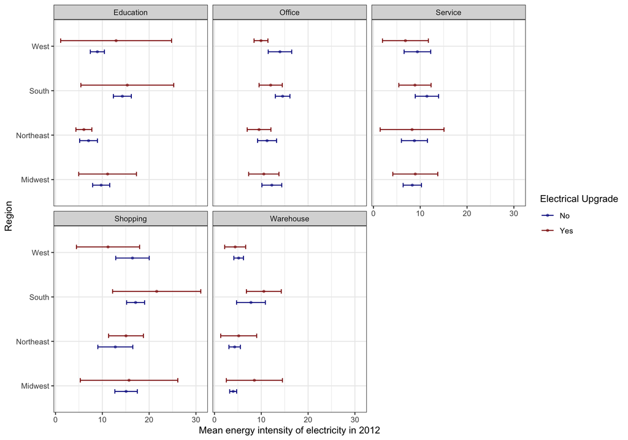

**Figure 1.** *Energy intensity of electricity* This figure shows estimated mean energy intensity of electricity in 2012.

```r
cap1 = paste0(
  "**Figure 1.** *Energy intensity of electricity* ",
  "This figure shows estimated mean energy intensity of electricity in 2012."
)
results %>%
  mutate(
    `Primary Building Activity` = activity,
    `Electrical Upgrade` = RENELC
  ) %>%
  ggplot( aes(y = Mean, x = REGION, color = `Electrical Upgrade`) ) +
  geom_point( position = position_dodge(width = .5), alpha = 0.5, size = 1) +
  geom_errorbar(
    aes(ymin = LowerCLMean, ymax = UpperCLMean),
    position = position_dodge(width = .5),
    width = .2
  ) +
  coord_flip() +
  facet_wrap(~ `Primary Building Activity`) +
  theme_bw() +
  scale_color_manual(values = c('darkblue', 'darkred')) +
  ylab( "Mean energy intensity of electricity in 2012" ) +
  xlab('Region')
```

### Table

```r
cap2 = paste0("**Table 1.** *Energy intensity of Electricity in 2012* ",
              "Numbers in parantheses represent 95% confidence intervals.")

res = results %>%
  transmute(
    `Region` = REGION,
    `Primary Building Activity` = activity,
    `Electrical Upgrade` = RENELC,
    `Mean energy intensity` =
      sprintf('<div>%4.2f</div> <div>(%4.2f, %4.2f)</div>',
                     Mean, LowerCLMean,UpperCLMean),
    `se` = StdErr,
    `lwr` = LowerCLMean,
    `upr` = UpperCLMean,
    `est` = Mean
  )

tab1 = res %>%
  filter(`Electrical Upgrade` == 'Yes')

tab2 = res %>%
  filter(`Electrical Upgrade` == 'No')

diff = tab1 %>%
  left_join(
    tab2, by = c("Region", "Primary Building Activity")
    ) %>%
  transmute(
    Region, `Primary Building Activity`,
    diff = est.x - est.y,
    se = sqrt(se.x + se.y),
    lwr = diff - 1.96 * se,
    upr = diff + 1.96 * se,
    difference = sprintf('<div>%4.2f</div> <div>(%4.2f, %4.2f)</div>',
                     diff, lwr, upr),
    )

tab3 = left_join(
  select(tab1, c(1, 2, 4)),
  select(tab2, c(1, 2, 4)),
  by = c('Region', 'Primary Building Activity')) %>%
  left_join(
    select(diff, c(1, 2, 7)), by = c('Region', 'Primary Building Activity'))

tab4 = diffmean %>%
  filter(`activity` == `_activity`& `REGION` == `_REGION`) %>%
  transmute(
    `Region` = REGION,
    `Primary Building Activity` = activity,
    `p-value` = Probt
  )

tab3 %>%
  left_join(tab4, by = c('Region', 'Primary Building Activity')) %>%
  select(
    Region, `Primary Building Activity`,
    `Yes` = `Mean energy intensity.x`,
    `No` = `Mean energy intensity.y`,
    `Diff` = difference,
    `p-value`) %>%
  knitr::kable(
    format = 'html',
    escape = FALSE,
    align = 'llcccc',
    cap = cap2
  ) %>%
  kableExtra::kable_styling("striped", full_width = TRUE) %>%
  kableExtra::add_header_above(
  header = c(' ' = 2, 'Electrical Upgrade' = 2, ' ' = 2))
```

**Table 1.** *Energy intensity of Electricity in 2012* Numbers in parantheses represent 95% confidence intervals.

| Region | Primary Building Activity | Electrical Upgrade Yes | Electrical Upgrade No | Diff | p-value |
| --- | --- | --- | --- | --- | --- |
| Northeast | Education | 6.06 (4.35, 7.76) | 7.06 (5.16, 8.95) | -1.00 (-3.65, 1.65) | 0.4867 |
| Northeast | Office | 9.52 (6.99, 12.06) | 11.24 (9.21, 13.27) | -1.71 (-4.69, 1.27) | 0.2880 |
| Northeast | Service | 8.25 (1.43, 15.08) | 8.76 (5.97, 11.54) | -0.50 (-4.83, 3.82) | 0.8951 |
| Northeast | Shopping | 15.05 (11.34, 18.77) | 12.77 (9.04, 16.51) | 2.28 (-1.53, 6.09) | 0.3634 |
| Northeast | Warehouse | 5.18 (1.33, 9.02) | 4.31 (3.09, 5.54) | 0.86 (-2.28, 4.00) | 0.6764 |
| Midwest | Education | 11.12 (4.96, 17.29) | 9.75 (7.93, 11.58) | 1.37 (-2.58, 5.32) | 0.6513 |
| Midwest | Office | 10.54 (7.30, 13.78) | 12.25 (10.13, 14.38) | -1.71 (-4.95, 1.52) | 0.3805 |
| Midwest | Service | 8.94 (4.14, 13.75) | 8.31 (6.34, 10.27) | 0.64 (-2.99, 4.27) | 0.7643 |
| Midwest | Shopping | 15.70 (5.29, 26.12) | 15.08 (12.67, 17.48) | 0.63 (-4.37, 5.63) | 0.8914 |
| Midwest | Warehouse | 8.52 (2.53, 14.51) | 3.99 (3.25, 4.74) | 4.53 (0.91, 8.15) | 0.1500 |
| South | Education | 15.33 (5.41, 25.26) | 14.28 (12.36, 16.20) | 1.06 (-3.75, 5.86) | 0.8406 |
| South | Office | 12.01 (9.53, 14.49) | 14.56 (13.00, 16.12) | -2.55 (-5.36, 0.25) | 0.0821 |
| South | Service | 8.87 (5.43, 12.31) | 11.43 (8.93, 13.92) | -2.56 (-5.96, 0.84) | 0.2479 |
| South | Shopping | 21.61 (12.19, 31.04) | 17.11 (15.19, 19.03) | 4.51 (-0.19, 9.21) | 0.3451 |
| South | Warehouse | 10.54 (6.82, 14.27) | 7.79 (4.72, 10.87) | 2.75 (-0.89, 6.39) | 0.2472 |
| West | Education | 12.94 (1.09, 24.79) | 8.94 (7.43, 10.45) | 4.00 (-1.10, 9.10) | 0.5159 |
| West | Office | 9.94 (8.45, 11.42) | 13.99 (11.48, 16.50) | -4.06 (-6.84, -1.27) | 0.0015 |
| West | Service | 6.83 (1.93, 11.74) | 9.39 (6.55, 12.24) | -2.56 (-6.45, 1.33) | 0.3640 |
| West | Shopping | 11.22 (4.47, 17.96) | 16.44 (12.86, 20.02) | -5.22 (-9.71, -0.74) | 0.1573 |
| West | Warehouse | 4.42 (2.18, 6.66) | 5.17 (4.14, 6.19) | -0.74 (-3.27, 1.78) | 0.5176 |

We can also notice that the 95% CIs for buildings with upgrades are much wider.

## **Conclusion**

- There is no evident drops in electricity consumption after recent electrical upgrades.

### Limitation

- There might be other confounders that will affect the electricity consumption for example, whether electricity is the main source of energy or the building depends more on other energy.
- The number of observations is too small for each group, leading to large variances. Thus, it is hard to get a general answer to the question.